# My R Codes For Data Analysis

In this repository I am going to collect `R codes` for data analysis. Codes are from various resources and I try to give original link as much as possible.

[Serdar Balcı, MD, Pathologist](https://www.serdarbalci.com/)

2018-12-17

```r
knitr::opts_chunk$set(
    error = TRUE,
    message = FALSE,
    warning = FALSE
)
```

rstudioapi::selectDirectory()

xaringan:::inf_mr()

**Load required packages**

`Load required packages`

- Load required packages

> Gerekli paketleri yükle

```r
library(tidyverse)
```

# 1 tips

```r
my_string1 <- "3+4"
my_string2 <- "plot(cars)"
eval(parse(text = my_string1))
```

```
[1] 7
```

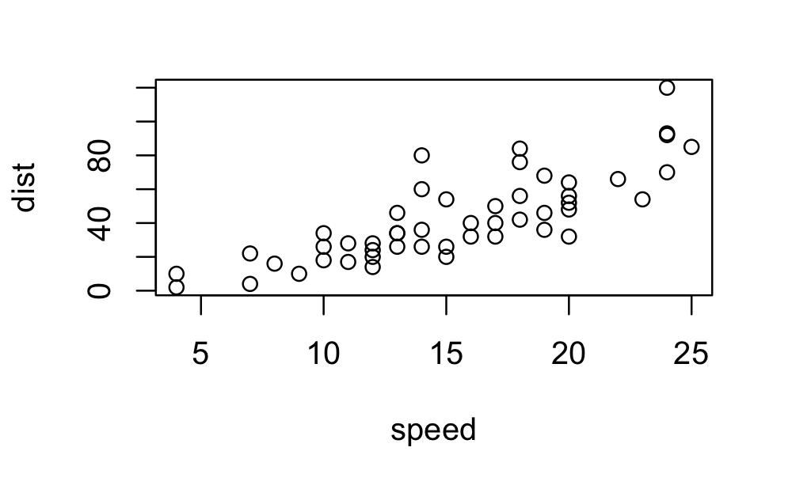

```r
eval(parse(text = my_string2))
```

# 2 environment memory

http://r-statistics.co/R-Tutorial.html

As you create new variables, by default they get store in what is called a global environment.

a <- 10 b <- 20 ls() # list objects in global env rm(a) # delete the object ‘a’ rm(list = ls()) # caution: delete all objects in .GlobalEnv gc() # free system memory

However if you choose, you can create a new environment and store them there.

rm(list=ls()) # remove all objects in work space env1 <- new.env() # create a new environment assign(“a”, 3, envir = env1) # store a=3 inside env1 ls() # returns objects in .GlobalEnv ls(env1) # returns objects in env1 get(‘a’, envir=env1) # retrieve value from env1

sort(vec1) # ascending sort sort(vec1, decreasing = TRUE) # Descending sort Sorting can also be achieved using the order() function which returns the indices of elements in ascending order.

vec1[order(vec1)] # ascending sort vec1[rev(order(vec1))] # descending sort

seq(1, 10, by = 2) # diff between adj elements is 2 seq(1, 10, length=25) # length of the vector is 25 rep(1, 5) # repeat 1, five times. rep(1:3, 5) # repeat 1:3, 5 times rep(1:3, each=5) # repeat 1 to 3, each 5 times.

subset(airquality, Day == 1, select = -Temp) # select Day=1 and exclude ‘Temp’ airquality[which(airquality$Day==1), -c(4)] # same as above

set.seed(100) trainIndex <- sample(c(1:nrow(airquality)), size=nrow(airquality)*0.7, replace=F) # get test sample indices airquality[trainIndex, ] # training data airquality[-trainIndex, ] # test data

if(checkConditionIfTrue) { ….statements.. ….statements.. } else { # place the ‘else’ in same line as ‘}’ ….statements.. ….statements.. }

for(counterVar in c(1:n)){ …. statements.. }